# PSYC40940: Major visualisation tools

## General outline for weeks 2 – 5

- Week 2: Principles of data visualisation
- Week 3: Grammar of graphics; aesthetics and attributes
- Week 4: Major visualisation tools
- Week 5: Customising visualisations (scales, themes, and labels)

## Checking up on the formative assessment

- Identify a data set for formative assessment.
- Work on visualisation for your data set.

## Objectives for today

- Appreciate the wide range of different visualisation tools
- Understand and explain what “geometries” are.
- Differentiate three major visualisation tools, when to use them, and how to create them in `ggplot2`.
- Explain why barplots are problematic for certain data types.
- Use data wrangling to adjust data to your visualisation goals.

Download exercises from Week 4 folder on NOW and move them into your R-project directory.

## Warm-up

From the top of your head, what types of data visualisations have you seen in journal articles / news / social media etc.?

## The list goes on forever

**Basic Charts**

- Bar Chart: compares quantities across categories.
- Column Chart: vertical version of a bar chart.
- Line Chart: shows trends over time.
- Pie Chart: shows proportions of a whole.
- Donut Chart: like a pie chart but with a blank center.
- Area Chart: like a line chart but filled below the line.

**Statistical Visualisations**

- Histogram: shows distribution of numerical data.
- Box Plot (Box-and-Whisker Plot): displays data spread and outliers.
- Violin Plot: combines box plot and density plot.
- Scatter Plot: shows relationships between two variables.
- Bubble Chart: scatter plot with a third variable represented by bubble size.

**Multivariate Visualisations**

- Heatmap: uses color to represent values in a matrix.
- Pair Plot: shows scatter plots for all variable combinations.
- Parallel Coordinates Plot: compares many variables across observations.
- Radar Chart (Spider Chart): compares multiple variables on axes from a central point.

**Geospatial Visualisations**

- Choropleth Map: uses color to show data across geographic regions.
- Dot Map: uses dots to show data density.
- Heat Map (Geospatial): shows intensity of data over a map.
- Flow Map: shows movement between locations.

**Hierarchical & Network Visualisations**

- Tree Map: nested rectangles showing hierarchical data.
- Sunburst Chart: radial version of a tree map.
- Dendrogram: tree diagram showing hierarchical clustering.
- Network Graph: shows relationships between entities (nodes and edges).
- Sankey Diagram: shows flow and proportions between stages.

**Temporal Visualisations**

- Gantt Chart: shows project timelines.
- Timeline: displays events in chronological order.
- Calendar Heatmap: shows data across days/weeks/months.

**Specialised Visualisations**

- Word Cloud: visualises text data by word frequency.
- Contour Plot: shows 3D surface on 2D plane.
- Streamgraph: variation of stacked area chart for time series.
- Ternary Plot: shows proportions of three variables that sum to a constant.

## Here with some more system

Decision tree from data-to-viz.com/

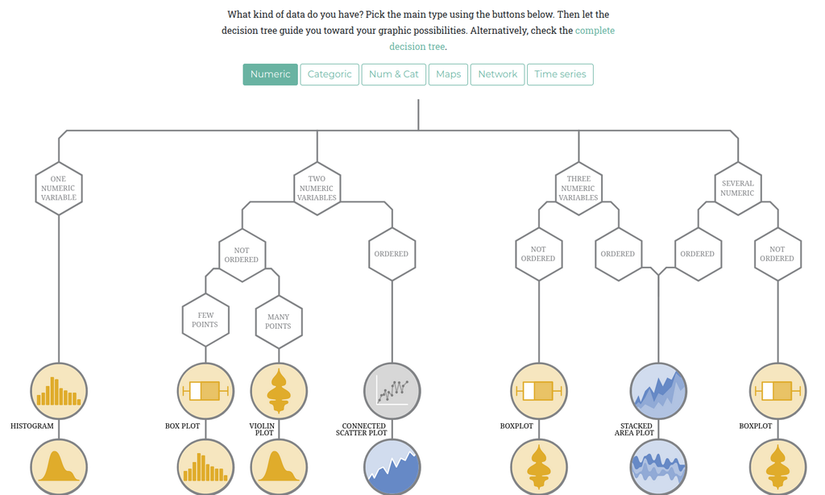

## Major visualisation tools

## Geometries

- choice depends on visualisation goals, number and type of variables (and your subject domain)
- what kind of visual element you want to draw?
- a geometry (or geom) is the type of plot layer that tells *R* how to represent the data visually.

Think of it like this:

- you have data (e.g., heights of children, test scores, etc.).
- you want to show it visually.
- the **geom** decides *how* it appears: as points, lines, bars, boxes, etc.
- **geoms** are your drawing toolkit

## Geometries

- Geometries (`geom_`) control visual encoding of aesthetics layer
- ~50 geometries: `geom_` are part of `ggplot2` (below)
- more `geoms` in other packages such as `ggdist`, `ggbeeswarm`, and `ggridges`
- many can be combined

```
 [1] abline            area              bar               bin_2d
 [5] bin2d             blank             boxplot           col
 [9] column            contour           contour_filled    count
[13] crossbar          curve             density           density_2d
[17] density_2d_filled density2d         density2d_filled  dotplot
[21] errorbar          errorbarh         freqpoly          function
[25] hex               histogram         hline             jitter
[29] label             line              linerange         map
[33] path              point             pointrange        polygon
[37] qq                qq_line           quantile          raster
[41] rect              ribbon            rug               segment
[45] sf                sf_label          sf_text           smooth
[49] spoke             step              text              tile
[53] violin            vline
```

## Common geometries and their uses

| Geometry | Function | What it shows |
| --- | --- | --- |
| `geom_point()` | Scatter plot | Relationship between two variables |
| `geom_line()` | Line plot | Trends over time or ordered categories |
| `geom_bar()` | Bar chart | Counts or values for categories |
| `geom_histogram()` | Histogram | Distribution of a single variable |
| `geom_boxplot()` | Boxplot | Summary of distribution (median, quartiles, outliers) |
| `geom_text()` | Text labels | Add labels to points or bars |

## Same data, different geometries

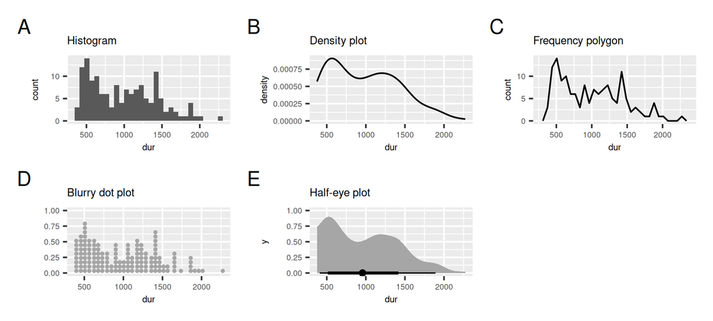

## Major visualisation types

- univariate distributions
- bivariate distributions
- group comparisons

## Univariate distribution

- function: distribution of values
- variable type: continuous or discrete
- examples: histograms, density plots, bar plots, rug

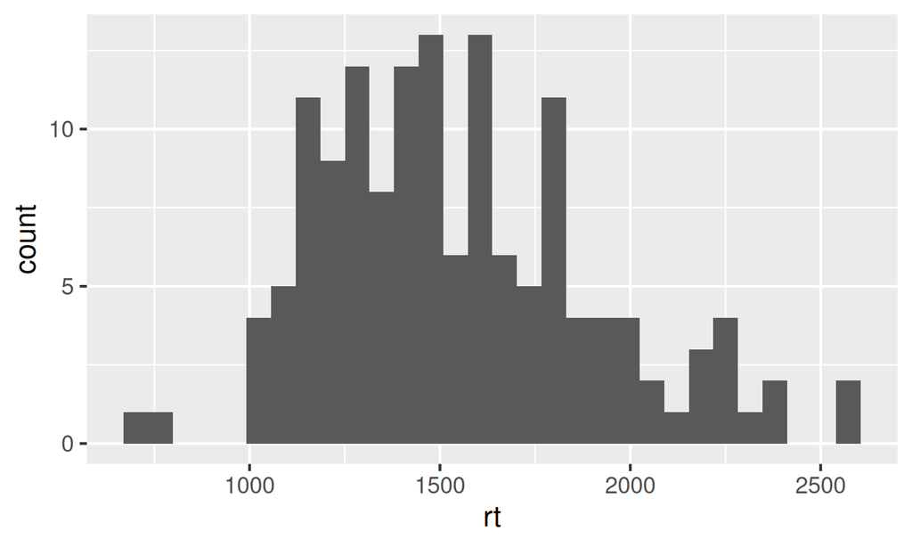

```r
ggplot(d_spellname, aes(x = rt)) +
  geom_histogram()
```

## Univariate distribution

Complete RMarkdown document **1_univariate_viz.Rmd**

## Bivariate distribution

- function: relationship between two variables
- variable type: typically continuous
- examples: scatter plot, time series

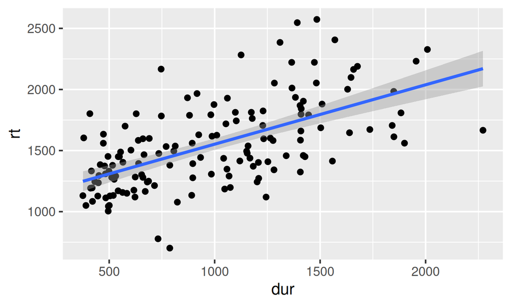

## Bivariate distribution

- function: relationship between two variables
- variable type: typically continuous
- examples: scatter plot, time series

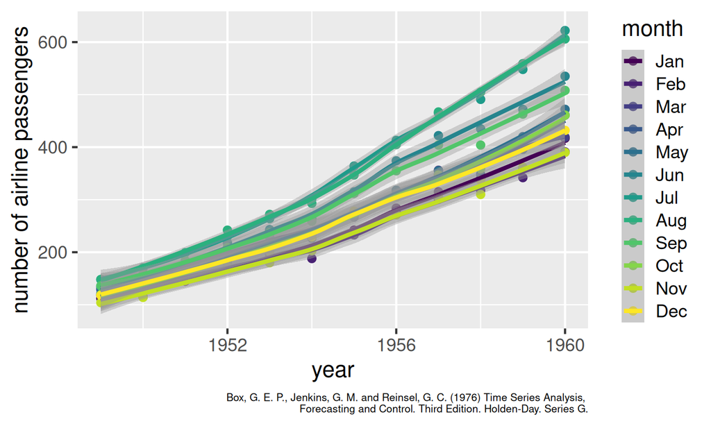

## Bivariate distribution

- function: relationship between two variables
- variable type: typically continuous
- examples: scatter plot, time series

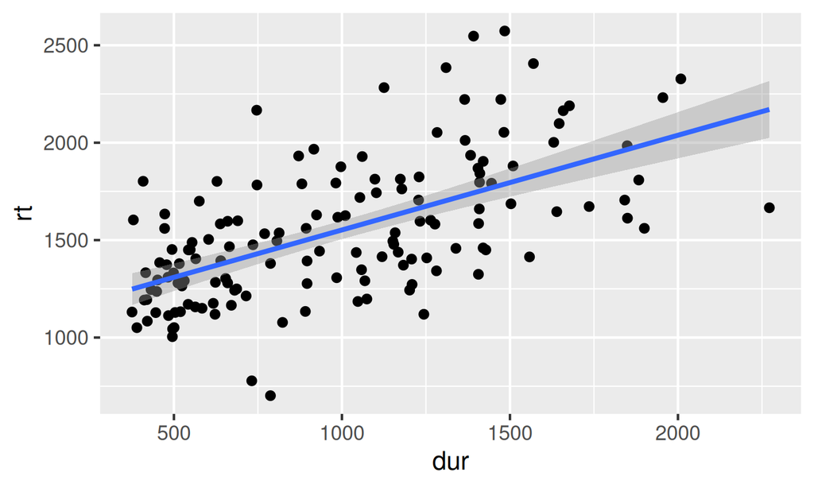

## Bivariate distribution

- function: relationship between two variables
- variable type: typically continuous
- examples: scatter plot, time series

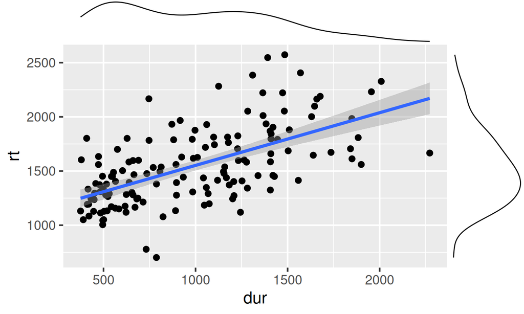

## Bivariate distribution

- function: relationship between two variables
- variable type: typically continuous
- examples: scatter plot, time series

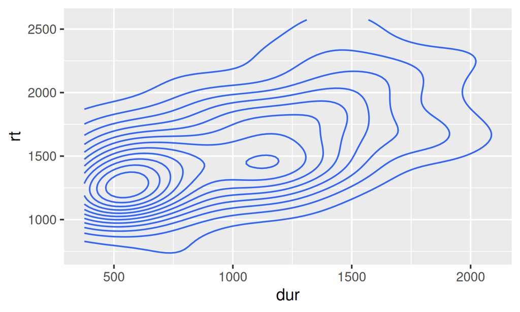

## Bivariate distribution

- function: relationship between two variables
- variable type: typically continuous
- examples: scatter plot, time series

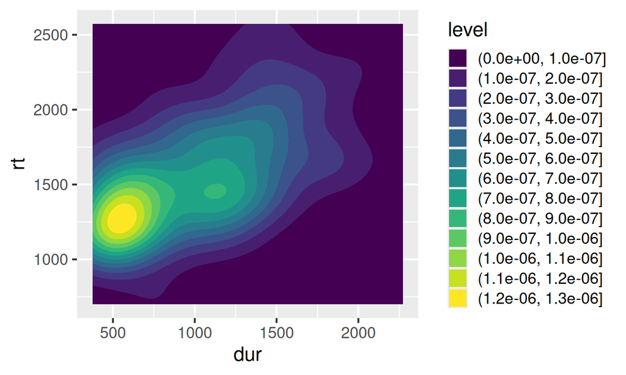

## Bivariate distribution

- function: relationship between two variables
- variable type: typically continuous
- examples: scatter plot, time series

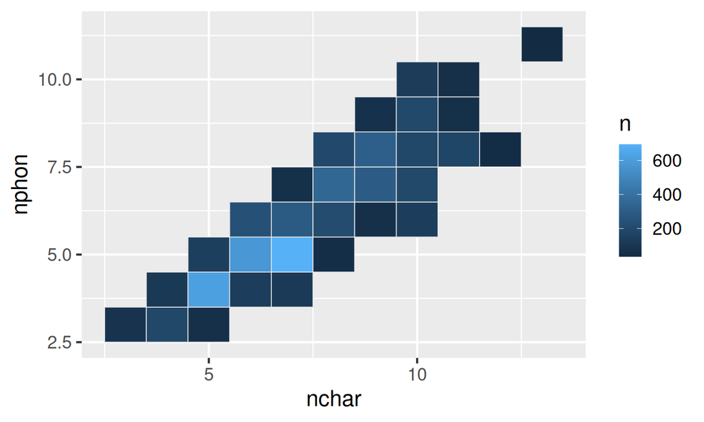

## Bivariate distributions: interactivity

Any `ggplot2` object can easily be transformed into an interactive visualisation using the `plotly` package.

```r
# Load plotly package
library(plotly)

# Create ggplot plot and save in `plot`
plot <- ggplot(d_spellname, aes(x = dur, y = rt)) +
  geom_point()

# Create an interactive version of `plot` using `ggplotly`
ggplotly(plot)
```

[interactive chart not shown]

## Bivariate distribution

Complete RMarkdown document **2_bivariate_viz.Rmd**

## Groups comparison

- function: distribution of values for two or more groups (often closely tied to statistical descriptions)
- variable type: continuous
- examples: (jitter) dots, box plot, violin plot, beeswarm plots, barplot (pie chart), dynamite plots

## Dynamite plot and its pitfalls

What problems can you think of?

## Dynamite plot and its pitfalls

- normal distribution
- same number of observations in each group
- presence of data where there are none?
- absence of data above the errorbars

Now watch what happens to the y-axis when we use dots.

## Alternative geometries: points

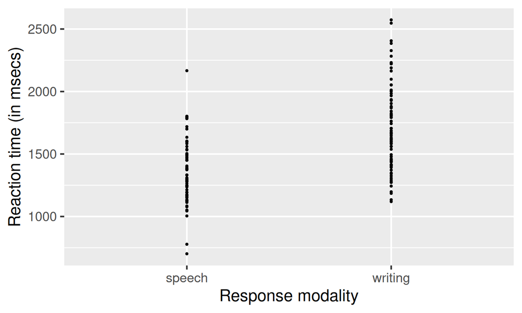

## Alternative geometries: jittered points

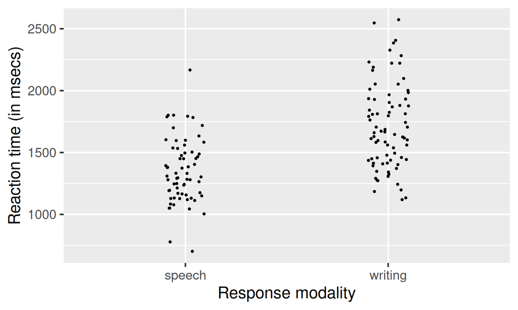

## Alternative geometries: points and errorbars

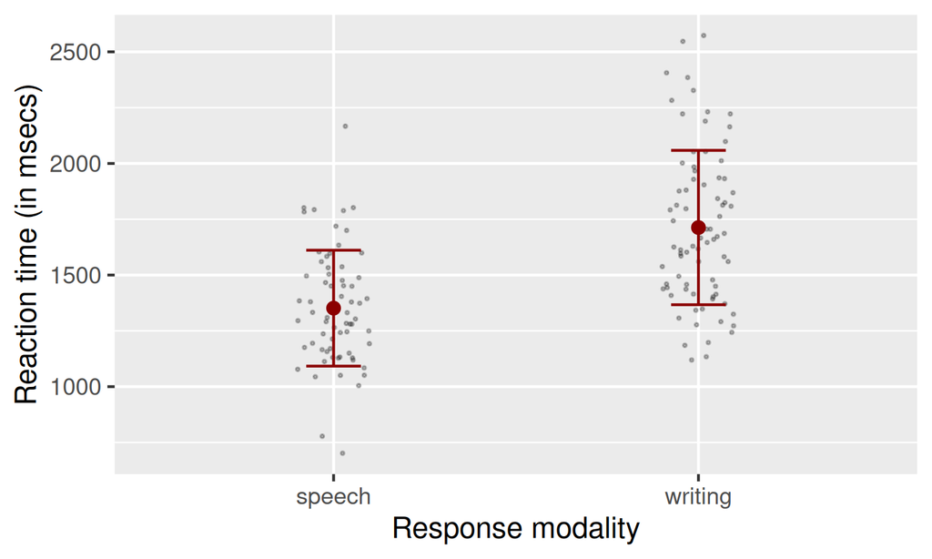

## Alternative geometries: box-and-whiskers plot

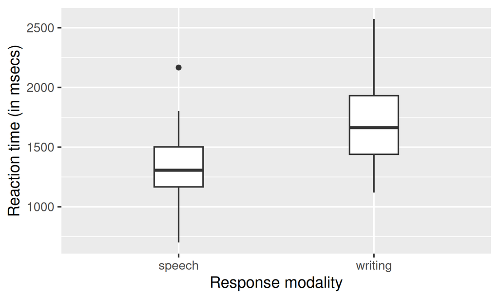

## Alternative geometries: box-and-whiskers plot

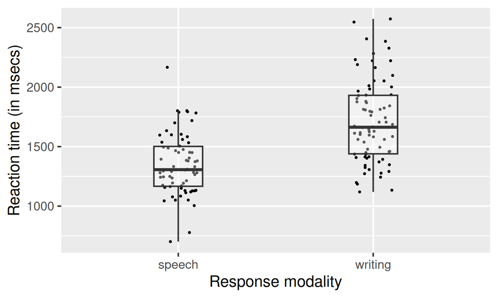

## Alternative geometries: box-and-whiskers plot

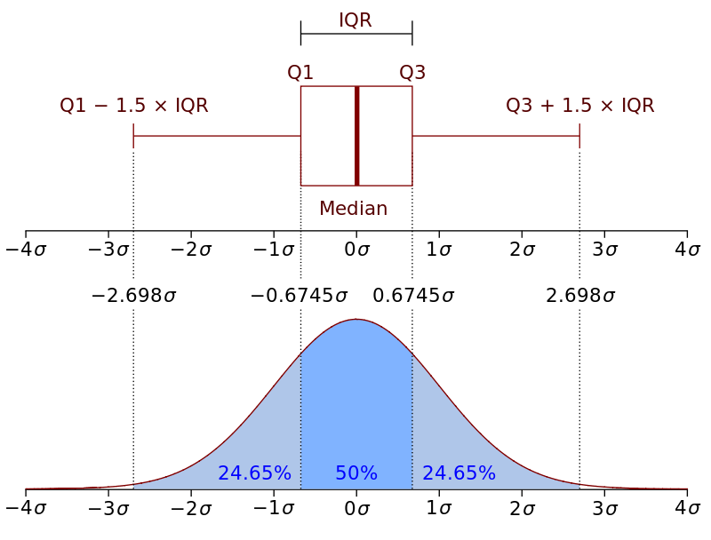

See Tukey (1977)

## Raincloud plots

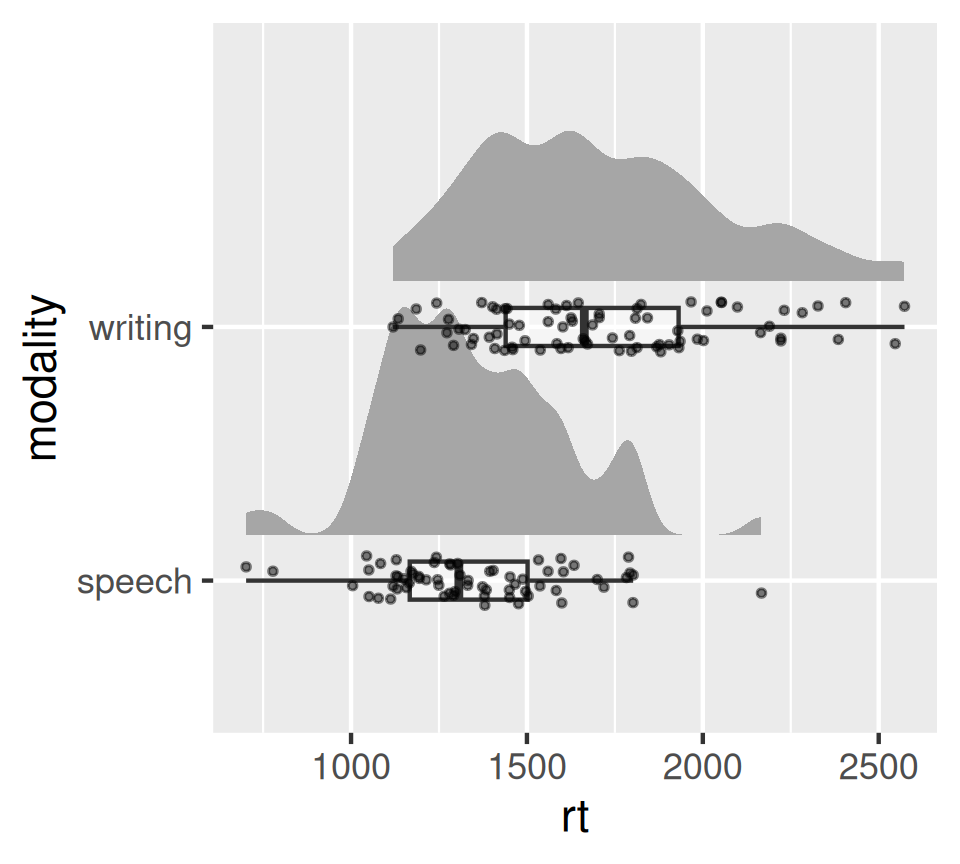

```r
library(ggdist)

ggplot(d_spellname, aes(x = modality, y = rt)) +
  # half violin (the "cloud")
  stat_halfeye(
    adjust = 0.45,        # smoothness
    justification = -0.2, # shift left/right
    .width = 0,           # no interval bars
    point_colour = NA) +
  # boxplot
  geom_boxplot(
    width = 0.15,
    outlier.shape = NA,
    alpha = 0.5) +
  # jittered points (the "rain")
  geom_jitter(
    width = 0.1,
    alpha = 0.5,
    size = 1) +
  coord_flip() # horizontal orientation
```

## Group comparisons

Complete RMarkdown document **3_group_comparisons.Rmd**

## Crash course in data wrangling

- Data come in various formats.
- For some visualisations, the format of the data needs to be changed.

You’ve already seen these:

```r
# Count number of identical observations
count(data, group)

# Calculate descriptive statistics
summarise(data, mean = mean(rt))

# Remove rows with missing data (i.e. NA)
drop_na()
```

## Crash course in data wrangling

- `dplyr` has many useful functions for data wrangling.
- Knowing the following functions will give you a lot of flexibility.

```r
# Transforms dataframes into a long format
pivot_longer(data, cols)

# Transforms dataframes into a wide format
pivot_wider(data, names_from, values_from)

# Selects and removes variables
select(data, var1, var2)

# Retains and removes observations
filter(data, condition)

# Creates new variables
mutate(data, new_var = old_var)
```

Complete RMarkdown document **4_data_wrangling.Rmd**

## Homework

- Complete RMarkdown document **4_data_wrangling.Rmd**
- Bring in data and anything you’ve already done for the formative assessment.
- Complete recommended reading

## Reading

Data visualisation with `ggplot2`

- [Chapters 3–5 of Wickham (2016)](https://ggplot2-book.org/scales-colour.html)
- [Chapter 3 of Wickham & Grolemund (2016)](https://r4ds.had.co.nz/transform.html)
- [Chapter 4 of Andrews (2021)](https://github.com/mark-andrews/ddsr/releases/download/v22.7.31/chapter_04_visualization.pdf)

Data wrangling with `dplyr` / `tidyverse`

- [Chapter 3 of Andrews (2021)](https://github.com/mark-andrews/ddsr/releases/download/v22.7.31/chapter_03_wrangling.pdf)
- [Chapter 5 of Wickham & Grolemund (2016)](https://r4ds.had.co.nz/transform.html)

## References

Andrews, M. (2021). *Doing data science in R: An introduction for Social Scientists*. SAGE Publications Ltd.

Tukey, J. W. (1977). *Exploratory data analysis* (Vol. 2).

Wickham, H. (2016). *ggplot2: Elegant graphics for data analysis*. Springer.

Wickham, H., & Grolemund, G. (2016). *R for data science: Import, tidy, transform, visualize, and model data*. O’Reilly Media, Inc.